# Assignment 2

## Submit as an HTML file

Print your ID below (do not input your name)

```python
id = 2487073
print(id)
```

```
2487073
```

(a) Import the pandas and matplotlib packages

```python
import pandas as pd
import matplotlib.pyplot as plt
```

(b) Open the dataset "athletes.csv" in the "data" folder

- Read it as a pandas object called "athlete"
- Note: This is a dataset of all Olympic Athletes from 1896 to 2022

```python
athlete = pd.read_csv('data/athletes.csv')
athlete
```

|  | ID | Name | Sex | Age | Height | Weight | Team | NOC | Games | Year | Season | City | Sport | Event | Medal |
| --- | --- | --- | --- | --- | --- | --- | --- | --- | --- | --- | --- | --- | --- | --- | --- |
| 0 | 1 | A Dijiang | M | 24.0 | 180.0 | 80.0 | China | CHN | 1992 Summer | 1992 | Summer | Barcelona | Basketball | Basketball Men's Basketball | NaN |
| 1 | 2 | A Lamusi | M | 23.0 | 170.0 | 60.0 | China | CHN | 2012 Summer | 2012 | Summer | London | Judo | Judo Men's Extra-Lightweight | NaN |
| 2 | 3 | Gunnar Nielsen Aaby | M | 24.0 | 191.0 | 85.0 | Denmark | DEN | 1920 Summer | 1920 | Summer | Antwerpen | Football | Football Men's Football | NaN |
| 3 | 4 | Edgar Lindenau Aabye | M | 34.0 | NaN | NaN | Denmark/Sweden | DEN | 1900 Summer | 1900 | Summer | Paris | Tug-Of-War | Tug-Of-War Men's Tug-Of-War | Gold |
| 4 | 5 | Christine Jacoba Aaftink | F | 21.0 | 185.0 | 82.0 | Netherlands | NED | 1988 Winter | 1988 | Winter | Calgary | Speed Skating | Speed Skating Women's 500 metres | NaN |
| ... | ... | ... | ... | ... | ... | ... | ... | ... | ... | ... | ... | ... | ... | ... | ... |
| 271113 | 135570 | Piotr ya | M | 27.0 | 176.0 | 59.0 | Poland | POL | 2014 Winter | 2014 | Winter | Sochi | Ski Jumping | Ski Jumping Men's Large Hill, Team | NaN |
| 271114 | 135571 | Tomasz Ireneusz ya | M | 30.0 | 185.0 | 96.0 | Poland | POL | 1998 Winter | 1998 | Winter | Nagano | Bobsleigh | Bobsleigh Men's Four | NaN |
| 271115 | 135572 | Tomasz Ireneusz ya | M | 34.0 | 185.0 | 96.0 | Poland | POL | 2002 Winter | 2002 | Winter | Salt Lake City | Bobsleigh | Bobsleigh Men's Four | NaN |
| 271116 | 135573 | Pusarla Venkata Sindhu | F | 21.0 | 179.0 | 65.0 | India | IND | 2016 Summer | 2016 | Summer | Rio de Janeiro | Badminton | Badminton Women's | Silver |
| 271117 | 135574 | Pusarla Venkata Sindhu | NaN | 25.0 | 179.0 | 65.0 | India | IND | 2020 Summer | 2020 | Summer | Tokyo | Badminton | Badminton Women's | Bronze |

271118 rows × 15 columns

(c) View the dataset and create a list of variable names

```python
# Create a list, e.g. "variable_names = [ "name1", "name2", "name3" ]"
# Manually type the names of the first 4 variables (not including ID)
# If you're viewing the dataset from the VS-Code "Variables" tool, you'll see an extra column "index". Do not include this in your list.

variable_names = ["Name", "Sex", "Age", "Height"]
print(variable_names)
```

```
['Name', 'Sex', 'Age', 'Height']
```

(d) Compute descriptive statistics for the third variable in the dataset

- One way to do this is:

athlete["Age"].describe()

- Do something similar, but with the list you created above.
- Substitute "Age" with a command that automatically extracts the third element in the list

```python
# Remember that the numbering in Python starts at zero
# For example:
# list_colors = ["red","green","yellow"]
# list_colors[1] will output "green"

statistics = athlete[variable_names[2]].describe()
print(statistics)
```

```
count    261644.000000
mean         25.556879
std           6.393543
min          10.000000
25%          21.000000
50%          24.000000
75%          28.000000
max          97.000000
Name: Age, dtype: float64
```

(e) Show a scatter plot that shows "Height" in the x-axis and "Weight" in the y-axis.

- Label the axes for full points
- Note: This question does not depend on (d)
- Give a one sentence interpretation of the plot

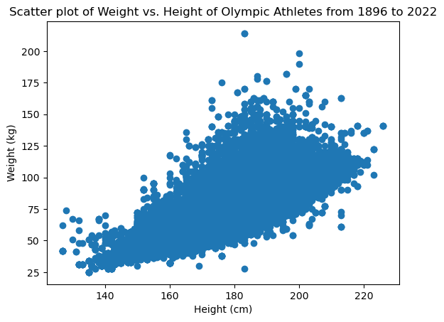

```python
plt.scatter(athlete["Height"], athlete["Weight"])

plt.xlabel("Height (cm)")
plt.ylabel("Weight (kg)")

plt.title("Scatter plot of Weight vs. Height of Olympic Athletes from 1896 to 2022")

plt.show()
```

Interpretation of the plot:

The scatter plot suggests that, generally, there's a positive correlation that athletes who are taller also weigh more, however for some athletes who are taller than about 185cm, their weight does not necessarily increase and can weigh less than athletes who are 185cm tall.